# Trait generation

```r
source('../env.R')
```

# Create measured traits database for Jetz Columbidae Taxonomy

Here we create traits based on the “AVONET: Morphological, Ecological and Geographical Data for All Birds.” (2022) morphology and trait database.

## Load Mapping Birdlife to Jetz

```r
birdlife_jetz_mapping = read_csv('/Users/james/Dropbox/PhD/BirdLife/Taxonomy/birdlife_v8_columbidae_taxonomy_to_jetz.csv')
birdlife_jetz_mapping
```

| SISRecID_v8 | SpcRecID_v8 | SpeciesName_v8 | CommonName_v8 | RedList2023 | Synonyms_v8 | SISRecID_v7 | SpcRecID_v7 | SpeciesName_v7 | CommonName_v7 | RedList2022 | Synonyms_v7 | SISRecID_v6 | SpcRecID_v6 | SpeciesName_v6 | CommonName_v6 | Synonyms_v6 | RedList2022_v6 | SISRecID_v5 | SpcRecID_v5 | SpeciesName_v5 | CommonName_v5 | Synonyms_v5 | RedList2022_v5 | SISRecID_v4 | SpcRecID_v4 | SpeciesName_v4 | CommonName_v4 | Synonyms_v4 | RedList2019 | … |
| --- | --- | --- | --- | --- | --- | --- | --- | --- | --- | --- | --- | --- | --- | --- | --- | --- | --- | --- | --- | --- | --- | --- | --- | --- | --- | --- | --- | --- | --- | --- |
| 22690066 | 2444 | Columba livia | Rock Dove | LC | NA | 22690066 | 2444 | Columba livia | Rock Dove | LC | NA | 22690066 | 2444 | Columba livia | Rock Dove | NA | LC | 22690066 | 2444 | Columba livia | Rock Dove | NA | LC | 22690066 | 2444 | Columba livia | Rock Dove | NA | LC | … |
| 22690074 | 2445 | Columba rupestris | Hill Pigeon | LC | NA | 22690074 | 2445 | Columba rupestris | Hill Pigeon | LC | NA | 22690074 | 2445 | Columba rupestris | Hill Pigeon | NA | LC | 22690074 | 2445 | Columba rupestris | Hill Pigeon | NA | LC | 22690074 | 2445 | Columba rupestris | Hill Pigeon | NA | LC | … |
| 22690077 | 2446 | Columba leuconota | Snow Pigeon | LC | NA | 22690077 | 2446 | Columba leuconota | Snow Pigeon | LC | NA | 22690077 | 2446 | Columba leuconota | Snow Pigeon | NA | LC | 22690077 | 2446 | Columba leuconota | Snow Pigeon | NA | LC | 22690077 | 2446 | Columba leuconota | Snow Pigeon | NA | LC | … |
| 22690080 | 2447 | Columba guinea | Speckled Pigeon | LC | NA | 22690080 | 2447 | Columba guinea | Speckled Pigeon | LC | NA | 22690080 | 2447 | Columba guinea | Speckled Pigeon | NA | LC | 22690080 | 2447 | Columba guinea | Speckled Pigeon | NA | LC | 22690080 | 2447 | Columba guinea | Speckled Pigeon | NA | LC | … |
| 22690084 | 2448 | Columba albitorques | White-collared Pigeon | LC | NA | 22690084 | 2448 | Columba albitorques | White-collared Pigeon | LC | NA | 22690084 | 2448 | Columba albitorques | White-collared Pigeon | NA | LC | 22690084 | 2448 | Columba albitorques | White-collared Pigeon | NA | LC | 22690084 | 2448 | Columba albitorques | White-collared Pigeon | NA | LC | … |
| 22690088 | 2449 | Columba oenas | Stock Dove | LC | NA | 22690088 | 2449 | Columba oenas | Stock Dove | LC | NA | 22690088 | 2449 | Columba oenas | Stock Dove | NA | LC | 22690088 | 2449 | Columba oenas | Stock Dove | NA | LC | 22690088 | 2449 | Columba oenas | Stock Dove | NA | LC | … |
| 22690097 | 2451 | Columba eversmanni | Yellow-eyed Pigeon | VU | NA | 22690097 | 2451 | Columba eversmanni | Yellow-eyed Pigeon | VU | NA | 22690097 | 2451 | Columba eversmanni | Yellow-eyed Pigeon | NA | VU | 22690097 | 2451 | Columba eversmanni | Yellow-eyed Pigeon | NA | VU | 22690097 | 2451 | Columba eversmanni | Yellow-eyed Pigeon | NA | VU | … |
| 22690092 | 2450 | Columba oliviae | Somali Pigeon | DD | NA | 22690092 | 2450 | Columba oliviae | Somali Pigeon | DD | NA | 22690092 | 2450 | Columba oliviae | Somali Pigeon | NA | DD | 22690092 | 2450 | Columba oliviae | Somali Pigeon | NA | DD | 22690092 | 2450 | Columba oliviae | Somali Pigeon | NA | DD | … |
| 22690103 | 2452 | Columba palumbus | Common Woodpigeon | LC | NA | 22690103 | 2452 | Columba palumbus | Common Woodpigeon | LC | NA | 22690103 | 2452 | Columba palumbus | Common Woodpigeon | NA | LC | 22690103 | 2452 | Columba palumbus | Common Woodpigeon | NA | LC | 22690103 | 2452 | Columba palumbus | Common Woodpigeon | NA | LC | … |
| 22690112 | 2453 | Columba trocaz | Madeira Laurel-pigeon | LC | NA | 22690112 | 2453 | Columba trocaz | Madeira Laurel-pigeon | LC | NA | 22690112 | 2453 | Columba trocaz | Madeira Laurel-pigeon | NA | LC | 22690112 | 2453 | Columba trocaz | Madeira Laurel-pigeon | NA | LC | 22690112 | 2453 | Columba trocaz | Madeira Laurel-pigeon | NA | LC | … |

[output cut: 343 more lines]

## Load Avonet Traits

```r
avonet_birdlife = read_csv('/Users/james/Dropbox/PhD/Avonet/TraitData/AVONET1_BirdLife.csv')
avonet_birdlife
```

| Sequence | Species1 | Family1 | Order1 | Avibase.ID1 | Total.individuals | Female | Male | Unknown | Complete.measures | Beak.Length_Culmen | Beak.Length_Nares | Beak.Width | Beak.Depth | Tarsus.Length | Wing.Length | Kipps.Distance | Secondary1 | Hand-Wing.Index | Tail.Length | Mass | Mass.Source | Mass.Refs.Other | Inference | Traits.inferred | Reference.species | Habitat | Habitat.Density | Migration | Trophic.Level | … |
| --- | --- | --- | --- | --- | --- | --- | --- | --- | --- | --- | --- | --- | --- | --- | --- | --- | --- | --- | --- | --- | --- | --- | --- | --- | --- | --- | --- | --- | --- | --- |
| 3103 | Accipiter albogularis | Accipitridae | Accipitriformes | AVIBASE-BBB59880 | 5 | 2 | 0 | 3 | 4 | 27.7 | 17.8 | 10.6 | 14.7 | 62.0 | 235.2 | 81.8 | 159.5 | 33.9 | 169.0 | 248.8 | Dunning | NA | NO | NA | NA | Forest | 1 | 2 | Carnivore | … |
| 3090 | Accipiter badius | Accipitridae | Accipitriformes | AVIBASE-1A0ECB6E | 10 | 4 | 6 | 0 | 8 | 20.6 | 12.1 | 8.8 | 11.6 | 43.0 | 186.7 | 62.5 | 127.4 | 32.9 | 140.6 | 131.2 | Dunning | NA | NO | NA | NA | Shrubland | 2 | 3 | Carnivore | … |
| 3125 | Accipiter bicolor | Accipitridae | Accipitriformes | AVIBASE-ADBE44E1 | 11 | 4 | 5 | 2 | 8 | 25.0 | 13.7 | 8.6 | 12.7 | 58.1 | 229.6 | 56.6 | 174.8 | 24.6 | 186.3 | 287.5 | Dunning | NA | NO | NA | NA | Woodland | 2 | 2 | Carnivore | … |
| 3116 | Accipiter brachyurus | Accipitridae | Accipitriformes | AVIBASE-68BF920B | 4 | 4 | 0 | 0 | 3 | 22.5 | 14.0 | 8.9 | 11.9 | 61.2 | 202.2 | 64.1 | 138.1 | 31.7 | 140.8 | 142.0 | Dunning | NA | NO | NA | NA | Forest | 1 | 2 | Carnivore | … |
| 3092 | Accipiter brevipes | Accipitridae | Accipitriformes | AVIBASE-8492E4B7 | 8 | 4 | 4 | 0 | 4 | 21.1 | 12.1 | 8.7 | 11.1 | 46.4 | 217.6 | 87.8 | 129.9 | 40.2 | 153.5 | 186.5 | Dunning | NA | NO | NA | NA | Forest | 1 | 3 | Carnivore | … |
| 3091 | Accipiter butleri | Accipitridae | Accipitriformes | AVIBASE-6B64C150 | 1 | 0 | 1 | 0 | 1 | 20.0 | 11.9 | 6.6 | 12.0 | 48.7 | 166.0 | 42.9 | 123.1 | 25.8 | 127.0 | 122.0 | Updated_literature | Dunning (2021) | NO | NA | NA | Forest | 1 | 1 | Carnivore | … |
| 3089 | Accipiter castanilius | Accipitridae | Accipitriformes | AVIBASE-9D80E72A | 6 | 2 | 2 | 2 | 4 | 20.5 | 11.5 | 8.3 | 10.9 | 52.6 | 163.5 | 38.9 | 123.1 | 24.0 | 135.4 | 157.5 | Dunning | NA | NO | NA | NA | Forest | 1 | 2 | Carnivore | … |
| 3115 | Accipiter cirrocephalus | Accipitridae | Accipitriformes | AVIBASE-21957C95 | 5 | 2 | 3 | 0 | 4 | 19.2 | 10.6 | 7.7 | 9.6 | 60.3 | 213.0 | 81.3 | 133.7 | 37.8 | 155.4 | 165.7 | Dunning | NA | NO | NA | NA | Forest | 1 | 2 | Carnivore | … |
| 3130 | Accipiter collaris | Accipitridae | Accipitriformes | AVIBASE-32760AD5 | 7 | 1 | 5 | 1 | 6 | 20.0 | 11.2 | 8.6 | 11.0 | 43.6 | 165.9 | 49.5 | 115.2 | 30.0 | 125.0 | 97.8 | Updated_literature | BoW | NO | NA | NA | Forest | 1 | 2 | Carnivore | … |
| 3123 | Accipiter cooperii | Accipitridae | Accipitriformes | AVIBASE-EB98812F | 5 | 2 | 3 | 0 | 4 | 25.4 | 13.9 | 8.6 | 13.2 | 62.0 | 241.2 | 77.8 | 163.5 | 32.3 | 188.4 | 429.7 | Dunning | NA | NO | NA | NA | Woodland | 2 | 3 | Carnivore | … |

[output cut: 990 more lines]

### Avonet Columbidae traits

```r
avonet_columbidae = avonet_birdlife[avonet_birdlife$Order1 == 'Columbiformes',]
avonet_columbidae
```

| Sequence | Species1 | Family1 | Order1 | Avibase.ID1 | Total.individuals | Female | Male | Unknown | Complete.measures | Beak.Length_Culmen | Beak.Length_Nares | Beak.Width | Beak.Depth | Tarsus.Length | Wing.Length | Kipps.Distance | Secondary1 | Hand-Wing.Index | Tail.Length | Mass | Mass.Source | Mass.Refs.Other | Inference | Traits.inferred | Reference.species | Habitat | Habitat.Density | Migration | Trophic.Level | … |
| --- | --- | --- | --- | --- | --- | --- | --- | --- | --- | --- | --- | --- | --- | --- | --- | --- | --- | --- | --- | --- | --- | --- | --- | --- | --- | --- | --- | --- | --- | --- |
| 894 | Alectroenas madagascariensis | Columbidae | Columbiformes | AVIBASE-F87511B3 | 4 | 2 | 2 | 0 | 4 | 17.5 | 9.2 | 4.1 | 4.2 | 22.3 | 171.0 | 57.5 | 113.5 | 33.6 | 81.5 | 173.0 | Dunning | NA | NO | NA | NA | Forest | 2 | 1 | Herbivore | … |
| 896 | Alectroenas pulcherrimus | Columbidae | Columbiformes | AVIBASE-576B77A3 | 5 | 2 | 2 | 1 | 4 | 20.6 | 9.4 | 4.5 | 4.8 | 25.5 | 160.4 | 40.8 | 121.0 | 25.2 | 81.2 | 165.0 | Dunning | NA | NO | NA | NA | Forest | 2 | 1 | Herbivore | … |
| 895 | Alectroenas sganzini | Columbidae | Columbiformes | AVIBASE-E396A643 | 5 | 2 | 3 | 0 | 4 | 19.3 | 8.8 | 4.4 | 4.3 | 25.3 | 164.2 | 50.2 | 113.5 | 30.7 | 93.0 | 158.0 | Dunning | NA | NO | NA | NA | Forest | 2 | 1 | Herbivore | … |
| 752 | Alopecoenas beccarii | Columbidae | Columbiformes | AVIBASE-51D9E97E | 4 | 2 | 2 | 0 | 4 | 15.6 | 9.1 | 2.1 | 2.8 | 27.5 | 103.0 | 30.5 | 72.5 | 29.6 | 55.5 | 78.7 | Dunning | NA | NO | NA | NA | Forest | 1 | 1 | Herbivore | … |
| 754 | Alopecoenas canifrons | Columbidae | Columbiformes | AVIBASE-40866A35 | 1 | 0 | 0 | 1 | 1 | 20.6 | 9.7 | 2.8 | 3.7 | 30.9 | 113.0 | 30.0 | 83.0 | 26.5 | 63.0 | 135.0 | Inferred | NA | YES | Body Mass | Alopecoenas jobiensis | Forest | 1 | 1 | Herbivore | … |
| 750 | Alopecoenas erythropterus | Columbidae | Columbiformes | AVIBASE-DD2985FA | 4 | 1 | 3 | 0 | 4 | 20.7 | 11.1 | 3.6 | 4.3 | 31.6 | 140.5 | 43.2 | 97.2 | 30.8 | 73.5 | 113.2 | Dunning | NA | NO | NA | NA | Woodland | 1 | 1 | Herbivore | … |
| 746 | Alopecoenas hoedtii | Columbidae | Columbiformes | AVIBASE-CD21DBC9 | 3 | 1 | 2 | 0 | 3 | 18.8 | 8.8 | 3.9 | 4.8 | 27.0 | 148.7 | 42.7 | 106.0 | 28.7 | 102.3 | 135.0 | Inferred | NA | YES | Body Mass | Alopecoenas jobiensis | Forest | 1 | 1 | Herbivore | … |
| 747 | Alopecoenas jobiensis | Columbidae | Columbiformes | AVIBASE-424F7705 | 5 | 0 | 5 | 0 | 4 | 18.4 | 9.6 | 3.4 | 4.1 | 26.9 | 144.2 | 49.8 | 94.5 | 34.5 | 86.0 | 135.0 | Dunning | NA | NO | NA | NA | Forest | 1 | 1 | Herbivore | … |
| 753 | Alopecoenas johannae | Columbidae | Columbiformes | AVIBASE-A8329D59 | 4 | 2 | 2 | 0 | 4 | 17.2 | 8.3 | 2.7 | 3.7 | 26.1 | 105.4 | 30.4 | 74.9 | 28.9 | 56.6 | 78.7 | DataFromSplit | NA | NO | NA | NA | Forest | 1 | 1 | Herbivore | … |
| 748 | Alopecoenas kubaryi | Columbidae | Columbiformes | AVIBASE-2E50E5DA | 4 | 2 | 2 | 0 | 4 | 21.1 | 11.2 | 3.4 | 4.8 | 32.4 | 146.0 | 40.8 | 105.2 | 27.8 | 81.2 | 162.0 | EltonTraits_Model | NA | NO | NA | NA | Forest | 1 | 1 | Omnivore | … |

[output cut: 343 more lines]

### Check we have all species from our mapping file (e.g. all species mapping to Birdlife V8 taxonomy)

Avonet uses Birdlife V5 taxonomy.

```r
birdlife_jetz_mapping[!(birdlife_jetz_mapping$SpeciesName_v5 %in% avonet_columbidae$Species1),]
```

| SISRecID_v8 | SpcRecID_v8 | SpeciesName_v8 | CommonName_v8 | RedList2023 | Synonyms_v8 | SISRecID_v7 | SpcRecID_v7 | SpeciesName_v7 | CommonName_v7 | RedList2022 | Synonyms_v7 | SISRecID_v6 | SpcRecID_v6 | SpeciesName_v6 | CommonName_v6 | Synonyms_v6 | RedList2022_v6 | SISRecID_v5 | SpcRecID_v5 | SpeciesName_v5 | CommonName_v5 | Synonyms_v5 | RedList2022_v5 | SISRecID_v4 | SpcRecID_v4 | SpeciesName_v4 | CommonName_v4 | Synonyms_v4 | RedList2019 | … |
| --- | --- | --- | --- | --- | --- | --- | --- | --- | --- | --- | --- | --- | --- | --- | --- | --- | --- | --- | --- | --- | --- | --- | --- | --- | --- | --- | --- | --- | --- | --- |

### Check which species we are losing from avonet

We can check that we are only losing species that are absent from Birdlife V8 by checking our Birdlife to Jetz mapping scripts.

```r
avonet_columbidae[!(avonet_columbidae$Species1 %in% birdlife_jetz_mapping$SpeciesName_v5),]
```

| Sequence | Species1 | Family1 | Order1 | Avibase.ID1 | Total.individuals | Female | Male | Unknown | Complete.measures | Beak.Length_Culmen | Beak.Length_Nares | Beak.Width | Beak.Depth | Tarsus.Length | Wing.Length | Kipps.Distance | Secondary1 | Hand-Wing.Index | Tail.Length | Mass | Mass.Source | Mass.Refs.Other | Inference | Traits.inferred | Reference.species | Habitat | Habitat.Density | Migration | Trophic.Level | … |
| --- | --- | --- | --- | --- | --- | --- | --- | --- | --- | --- | --- | --- | --- | --- | --- | --- | --- | --- | --- | --- | --- | --- | --- | --- | --- | --- | --- | --- | --- | --- |
| 868 | Ducula salvadorii | Columbidae | Columbiformes | AVIBASE-32DCE1CF | 4 | 2 | 2 | 0 | 4 | 29.4 | 19 | 8.1 | 7.2 | 32 | 248.9 | 77.8 | 171.2 | 31.2 | 135.3 | 756 | DataFromSplit | NA | NO | NA | NA | Forest | 2 | 1 | Herbivore | … |
| 890 | Ramphiculus meridionalis | Columbidae | Columbiformes | AVIBASE-E41C677F | 4 | 2 | 2 | 0 | 4 | 22.0 | 10 | 4.7 | 4.9 | 28 | 166.2 | 44.9 | 121.3 | 27.0 | 132.7 | 177 | DataFromSplit | NA | NO | NA | NA | Forest | 2 | 1 | Herbivore | … |

## Map traits to Jetz

```r
avonet_jetz = avonet_columbidae %>%
  inner_join(birdlife_jetz_mapping[,c('SpeciesName_v5', 'JetzSpeciesName')], by=c('Species1' = 'SpeciesName_v5')) %>%
  group_by(JetzSpeciesName) %>%
  summarise(
    beak_length_culmen = mean(Beak.Length_Culmen),
    beak_length_nares = mean(Beak.Length_Nares),
    beak_width = mean(Beak.Width),
    beak_depth = mean(Beak.Depth),
    tarsus_length = mean(Tarsus.Length),
    wing_length = mean(Wing.Length),
    kipps_distance = mean(Kipps.Distance),
    secondary1 = mean(Secondary1),
    handwing_index = mean(`Hand-Wing.Index`),
    tail_length = mean(Tail.Length),
    mass = mean(Mass),
    habitat = toString(unique(na.omit(Habitat))),
    habitat_density = toString(unique(na.omit(Habitat.Density))),
    migration =  toString(unique(na.omit(Migration))),
    trophic_level =  toString(unique(na.omit(Trophic.Level))),
    trophic_niche =  toString(unique(na.omit(Trophic.Niche))),
    primary_lifestyle =  toString(unique(na.omit(Primary.Lifestyle)))
  )

avonet_jetz
```

| JetzSpeciesName | beak_length_culmen | beak_length_nares | beak_width | beak_depth | tarsus_length | wing_length | kipps_distance | secondary1 | handwing_index | tail_length | mass | habitat | habitat_density | migration | trophic_level | trophic_niche | primary_lifestyle |
| --- | --- | --- | --- | --- | --- | --- | --- | --- | --- | --- | --- | --- | --- | --- | --- | --- | --- |
| Alectroenas_madagascariensis | 17.50000 | 9.200000 | 4.100000 | 4.200000 | 22.30000 | 171.0000 | 57.50000 | 113.50000 | 33.60000 | 81.50000 | 173.0000 | Forest | 2 | 1 | Herbivore | Frugivore | Insessorial |
| Alectroenas_pulcherrima | 20.60000 | 9.400000 | 4.500000 | 4.800000 | 25.50000 | 160.4000 | 40.80000 | 121.00000 | 25.20000 | 81.20000 | 165.0000 | Forest | 2 | 1 | Herbivore | Frugivore | Insessorial |
| Alectroenas_sganzini | 19.30000 | 8.800000 | 4.400000 | 4.300000 | 25.30000 | 164.2000 | 50.20000 | 113.50000 | 30.70000 | 93.00000 | 158.0000 | Forest | 2 | 1 | Herbivore | Frugivore | Insessorial |
| Aplopelia_larvata | 21.70000 | 19.000000 | 3.300000 | 3.700000 | 26.00000 | 143.1000 | 42.10000 | 101.70000 | 29.30000 | 92.90000 | 155.0000 | Forest | 2 | 1 | Herbivore | Granivore | Terrestrial |
| Caloenas_nicobarica | 30.70000 | 16.400000 | 5.400000 | 7.700000 | 43.70000 | 259.0000 | 85.50000 | 174.80000 | 32.80000 | 98.80000 | 537.9000 | Forest | 1 | 2 | Herbivore | Omnivore | Terrestrial |
| Chalcophaps_indica | 21.80000 | 11.000000 | 2.950000 | 4.100000 | 25.85000 | 147.9500 | 44.35000 | 101.70000 | 30.35000 | 85.45000 | 136.5000 | Forest | 1 | 1 | Herbivore | Omnivore | Generalist |
| Chalcophaps_stephani | 20.70000 | 9.500000 | 2.600000 | 3.800000 | 24.80000 | 136.0000 | 43.90000 | 91.60000 | 32.40000 | 84.40000 | 129.0000 | Forest | 3 | 1 | Herbivore | Omnivore | Generalist |
| Claravis_godefrida | 17.40000 | 10.800000 | 3.400000 | 3.700000 | 22.10000 | 118.0000 | 41.00000 | 77.00000 | 34.70000 | 81.80000 | 43.5000 | Forest | 1 | 2 | Herbivore | Granivore | Terrestrial |
| Claravis_mondetoura | 18.10000 | 7.000000 | 2.800000 | 3.600000 | 22.20000 | 116.9000 | 33.00000 | 83.50000 | 28.30000 | 81.30000 | 89.7000 | Forest | 1 | 2 | Herbivore | Granivore | Terrestrial |
| Claravis_pretiosa | 16.60000 | 9.800000 | 3.200000 | 3.600000 | 16.30000 | 110.8000 | 29.50000 | 81.40000 | 26.70000 | 76.10000 | 68.2000 | Forest | 1 | 2 | Herbivore | Granivore | Generalist |

[output cut: 294 more lines]

Check we have just one row per species

```r
length(unique(avonet_jetz$JetzSpeciesName)) == nrow(avonet_jetz)
```

```
[1] TRUE
```

### Check for mapping species that have two factor values

```r
avonet_jetz[
  grepl(',', avonet_jetz$habitat, fixed = TRUE) |
  grepl(',', avonet_jetz$habitat_density, fixed = TRUE) |
  grepl(',', avonet_jetz$migration, fixed = TRUE) |
  grepl(',', avonet_jetz$trophic_level, fixed = TRUE) |
  grepl(',', avonet_jetz$trophic_niche, fixed = TRUE) |
  grepl(',', avonet_jetz$primary_lifestyle, fixed = TRUE),
  c('JetzSpeciesName', 'habitat', 'habitat_density', 'migration', 'trophic_level', 'trophic_niche', 'primary_lifestyle')
]
```

| JetzSpeciesName | habitat | habitat_density | migration | trophic_level | trophic_niche | primary_lifestyle |
| --- | --- | --- | --- | --- | --- | --- |
| Macropygia_amboinensis | Forest | 1 | 1, 2 | Herbivore | Frugivore, Omnivore | Insessorial |
| Treron_calvus | Forest | 2 | 1, 2 | Herbivore | Frugivore | Insessorial |

```r
avonet_jetz[avonet_jetz$JetzSpeciesName %in% c('Columba_palumbus', 'Patagioenas_fasciata'),]
```

| JetzSpeciesName | beak_length_culmen | beak_length_nares | beak_width | beak_depth | tarsus_length | wing_length | kipps_distance | secondary1 | handwing_index | tail_length | mass | habitat | habitat_density | migration | trophic_level | trophic_niche | primary_lifestyle |
| --- | --- | --- | --- | --- | --- | --- | --- | --- | --- | --- | --- | --- | --- | --- | --- | --- | --- |
| Columba_palumbus | 27.80 | 13.1 | 8.0 | 7.80 | 31.50 | 246.4 | 101.40 | 145.00 | 41.20 | 153.2 | 490.0 | Woodland | 2 | 1 | Herbivore | Omnivore | Terrestrial |
| Patagioenas_fasciata | 25.35 | 15.1 | 5.8 | 6.15 | 26.35 | 205.9 | 74.15 | 131.25 | 36.05 | 141.5 | 366.3 | Forest | 2 | 1 | Herbivore | Granivore | Terrestrial |

```r
avonet_jetz$migration[avonet_jetz$JetzSpeciesName %in% c('Macropygia_amboinensis', 'Treron_calvus')] = '1'
```

Tropic niche of Macropygia amboinensis from avibase is Omnivore https://avibase.bsc-eoc.org/species.jsp?lang=EN&avibaseid=FD5160925CD583C1&sec=lifehistory

```r
avonet_jetz$trophic_niche[avonet_jetz$JetzSpeciesName %in% c('Macropygia_amboinensis')] = 'Omnivore'
```

### Should now have no species with dual factor values

```r
avonet_jetz[
  grepl(',', avonet_jetz$habitat, fixed = TRUE) |
  grepl(',', avonet_jetz$habitat_density, fixed = TRUE) |
  grepl(',', avonet_jetz$migration, fixed = TRUE) |
  grepl(',', avonet_jetz$trophic_level, fixed = TRUE) |
  grepl(',', avonet_jetz$trophic_niche, fixed = TRUE) |
  grepl(',', avonet_jetz$primary_lifestyle, fixed = TRUE),
  c('JetzSpeciesName', 'habitat', 'habitat_density', 'migration', 'trophic_level', 'trophic_niche', 'primary_lifestyle')
]
```

| JetzSpeciesName | habitat | habitat_density | migration | trophic_level | trophic_niche | primary_lifestyle |
| --- | --- | --- | --- | --- | --- | --- |

```r
avonet_jetz$habitat = as.factor(avonet_jetz$habitat)
avonet_jetz$habitat_density = as.factor(avonet_jetz$habitat_density)
avonet_jetz$migration = as.factor(avonet_jetz$migration)
avonet_jetz$trophic_level = as.factor(avonet_jetz$trophic_level)
avonet_jetz$trophic_niche = as.factor(avonet_jetz$trophic_niche)
avonet_jetz$primary_lifestyle = as.factor(avonet_jetz$primary_lifestyle)
```

# Generate composite traits

This uses a methodogy from Trisos (2014) and Tom P. Bregman and Tobias (2016) to create traits that describe a species lifestyle.

These traits are namely: * Overall body size. * trophic - beak shape (beak length, width, depth) - measures competitive exclusion (e.g. over-dispersion) via accentuation of foraging differences * locomotory (wing, tail, tarsus length) * tarsus-to-tail length ratio

## Trophic trait

```r
trophic_trait_pca = rda(avonet_jetz[,c('beak_length_culmen', 'beak_width', 'beak_depth')])
```

```r
avonet_jetz$trophic_pc1 = trophic_trait_pca$Ybar[,1]
avonet_jetz$trophic_pc2 = trophic_trait_pca$Ybar[,2]
avonet_jetz$trophic_pc3 = trophic_trait_pca$Ybar[,3]
```

How does PC1 explain trophic niche?

```r
trophic_pc1_aov = aov(trophic_pc1 ~ trophic_niche,
  data = avonet_jetz
)

summary(trophic_pc1_aov)
```

```
               Df Sum Sq Mean Sq F value        Pr(>F)
trophic_niche   2  3.676  1.8382   20.87 0.00000000326 ***
Residuals     301 26.514  0.0881
---
Signif. codes:  0 ‘***’ 0.001 ‘**’ 0.01 ‘*’ 0.05 ‘.’ 0.1 ‘ ’ 1
```

```r
summary(glht(trophic_pc1_aov,
  linfct = mcp(trophic_niche = "Tukey")
))
```

```
     Simultaneous Tests for General Linear Hypotheses

Multiple Comparisons of Means: Tukey Contrasts


Fit: aov(formula = trophic_pc1 ~ trophic_niche, data = avonet_jetz)

Linear Hypotheses:
                            Estimate Std. Error t value   Pr(>|t|)
Granivore - Frugivore == 0 -0.247299   0.040557  -6.098 < 0.000001 ***
Omnivore - Frugivore == 0   0.008417   0.044323   0.190       0.98
Omnivore - Granivore == 0   0.255716   0.050218   5.092 0.00000131 ***
---
Signif. codes:  0 ‘***’ 0.001 ‘**’ 0.01 ‘*’ 0.05 ‘.’ 0.1 ‘ ’ 1
(Adjusted p values reported -- single-step method)
```

How does PC2 explain trophic niche?

```r
trophic_pc2_aov = aov(trophic_pc2 ~ trophic_niche,
  data = avonet_jetz
)

summary(trophic_pc2_aov)
```

```
               Df Sum Sq Mean Sq F value              Pr(>F)
trophic_niche   2 0.7255  0.3627   63.96 <0.0000000000000002 ***
Residuals     301 1.7070  0.0057
---
Signif. codes:  0 ‘***’ 0.001 ‘**’ 0.01 ‘*’ 0.05 ‘.’ 0.1 ‘ ’ 1
```

```r
summary(glht(trophic_pc2_aov,
  linfct = mcp(trophic_niche = "Tukey")
))
```

```
     Simultaneous Tests for General Linear Hypotheses

Multiple Comparisons of Means: Tukey Contrasts


Fit: aov(formula = trophic_pc2 ~ trophic_niche, data = avonet_jetz)

Linear Hypotheses:
                           Estimate Std. Error t value Pr(>|t|)
Granivore - Frugivore == 0 -0.11184    0.01029 -10.868  < 0.001 ***
Omnivore - Frugivore == 0  -0.07054    0.01125  -6.272  < 0.001 ***
Omnivore - Granivore == 0   0.04131    0.01274   3.242  0.00377 **
---
Signif. codes:  0 ‘***’ 0.001 ‘**’ 0.01 ‘*’ 0.05 ‘.’ 0.1 ‘ ’ 1
(Adjusted p values reported -- single-step method)
```

How does PC3 explain trophic niche?

```r
trophic_pc3_aov = aov(trophic_pc3 ~ trophic_niche,
  data = avonet_jetz
)

summary(trophic_pc3_aov)
```

```
               Df Sum Sq Mean Sq F value               Pr(>F)
trophic_niche   2 0.5426  0.2713   40.48 0.000000000000000269 ***
Residuals     301 2.0171  0.0067
---
Signif. codes:  0 ‘***’ 0.001 ‘**’ 0.01 ‘*’ 0.05 ‘.’ 0.1 ‘ ’ 1
```

```r
summary(glht(trophic_pc3_aov,
  linfct = mcp(trophic_niche = "Tukey")
))
```

```
     Simultaneous Tests for General Linear Hypotheses

Multiple Comparisons of Means: Tukey Contrasts


Fit: aov(formula = trophic_pc3 ~ trophic_niche, data = avonet_jetz)

Linear Hypotheses:
                           Estimate Std. Error t value Pr(>|t|)
Granivore - Frugivore == 0 -0.10063    0.01119  -8.995  < 0.001 ***
Omnivore - Frugivore == 0  -0.03585    0.01223  -2.933  0.00996 **
Omnivore - Granivore == 0   0.06477    0.01385   4.676  < 0.001 ***
---
Signif. codes:  0 ‘***’ 0.001 ‘**’ 0.01 ‘*’ 0.05 ‘.’ 0.1 ‘ ’ 1
(Adjusted p values reported -- single-step method)
```

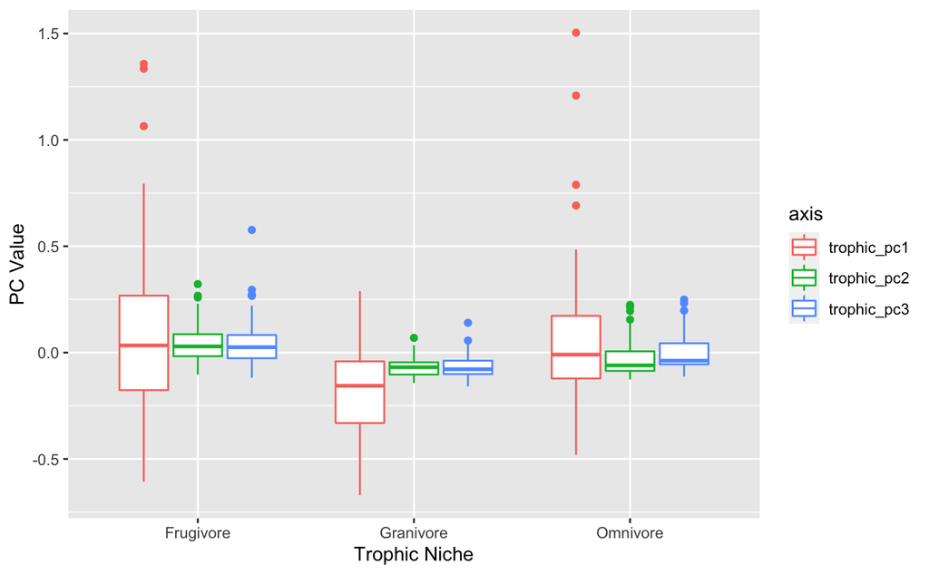

```r
avonet_jetz %>%
  pivot_longer(cols = c('trophic_pc1', 'trophic_pc2', 'trophic_pc3'), names_to = 'axis') %>%
  ggplot(aes(x = trophic_niche, y = value, color = axis)) +
    geom_boxplot() + xlab('Trophic Niche') + ylab('PC Value')
```

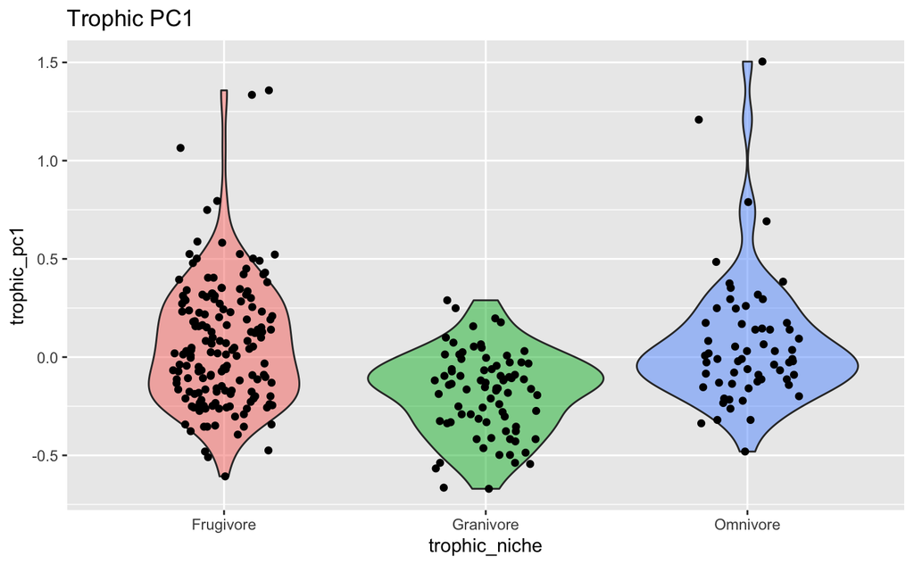

```r
avonet_jetz %>%
  ggplot(aes(x = trophic_niche, y = trophic_pc1, fill = trophic_niche)) +
    geom_violin(alpha = 0.5) +
    geom_point(position = position_jitter(seed = 1, width = 0.2)) +
    theme(legend.position = "none") +
    labs(title = "Trophic PC1")
```

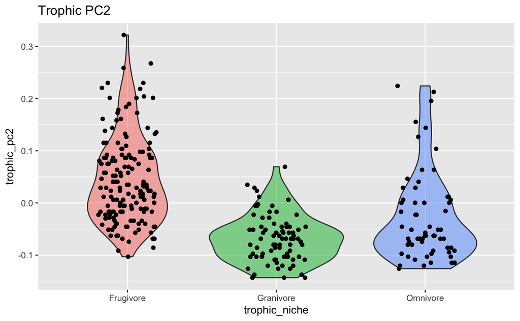

```r
avonet_jetz %>%
  ggplot(aes(x = trophic_niche, y = trophic_pc2, fill = trophic_niche)) +
    geom_violin(alpha = 0.5) +
    geom_point(position = position_jitter(seed = 1, width = 0.2)) +
    theme(legend.position = "none") +
    labs(title = "Trophic PC2")
```

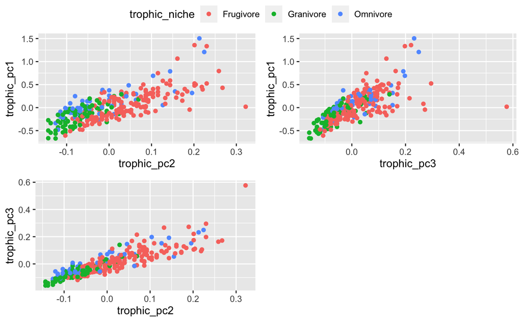

```r
ggarrange(ncol = 2, nrow = 2, common.legend = T,
          ggplot(avonet_jetz, aes(y = trophic_pc1, x = trophic_pc2, color = trophic_niche)) + geom_point(),
          ggplot(avonet_jetz, aes(y = trophic_pc1, x = trophic_pc3, color = trophic_niche)) + geom_point(),
          ggplot(avonet_jetz, aes(y = trophic_pc3, x = trophic_pc2, color = trophic_niche)) + geom_point()
)
```

Is PC1 correlated to mass?

```r
cor(avonet_jetz$trophic_pc1, avonet_jetz$mass)
```

```
[1] 0.7997893
```

Is PC2 correlated to mass?

```r
cor(avonet_jetz$trophic_pc2, avonet_jetz$mass)
```

```
[1] 0.6423876
```

Is PC3 correlated to mass?

```r
cor(avonet_jetz$trophic_pc3, avonet_jetz$mass)
```

```
[1] 0.5944833
```

## Locomotory trait

```r
loco_trait_pca = rda(avonet_jetz[,c('tarsus_length', 'wing_length', 'tail_length')])
summary(loco_trait_pca)
```

```
Call:
rda(X = avonet_jetz[, c("tarsus_length", "wing_length", "tail_length")])

Partitioning of variance:
              Inertia Proportion
Total            4004          1
Unconstrained    4004          1

Eigenvalues, and their contribution to the variance

Importance of components:
                           PC1       PC2      PC3
Eigenvalue            3599.459 350.94577 53.31631
Proportion Explained     0.899   0.08765  0.01332
Cumulative Proportion    0.899   0.98668  1.00000

Scaling 2 for species and site scores
* Species are scaled proportional to eigenvalues
* Sites are unscaled: weighted dispersion equal on all dimensions
* General scaling constant of scores:  33.18766


Species scores

                 PC1     PC2     PC3
tarsus_length  3.026  0.8724  3.7968
wing_length   25.061  5.8029 -0.4984
tail_length   18.788 -7.8810  0.0533


Site scores (weighted sums of species scores)

            PC1          PC2       PC3
sit1   -0.51315   2.55439912 -1.473133
sit2   -0.77734   1.97068701 -0.285657
sit3   -0.45789   1.23403715 -0.423677
sit4   -0.99167  -0.01969641  0.474162
sit5    2.10770   6.62482101  1.139124
sit6   -1.01073   0.87860796  0.243452
sit7   -1.33630   0.23657428  0.373900
```

[output cut: 282 more lines]

[output not shown]

```r
avonet_jetz$locomotory_pc1 = loco_trait_pca$Ybar[,1]
avonet_jetz$locomotory_pc2 = loco_trait_pca$Ybar[,2]
avonet_jetz$locomotory_pc3 = loco_trait_pca$Ybar[,3]
```

How does PC1 explain lifstyle?

```r
loco_lifstyle_pc1_aov = aov(locomotory_pc1 ~ primary_lifestyle,
  data = avonet_jetz
)

summary(loco_lifstyle_pc1_aov)
```

```
                   Df Sum Sq Mean Sq F value Pr(>F)
primary_lifestyle   2   1.77  0.8871    3.08 0.0474 *
Residuals         301  86.68  0.2880
---
Signif. codes:  0 ‘***’ 0.001 ‘**’ 0.01 ‘*’ 0.05 ‘.’ 0.1 ‘ ’ 1
```

```r
summary(glht(loco_lifstyle_pc1_aov,
  linfct = mcp(primary_lifestyle = "Tukey")
))
```

```
     Simultaneous Tests for General Linear Hypotheses

Multiple Comparisons of Means: Tukey Contrasts


Fit: aov(formula = locomotory_pc1 ~ primary_lifestyle, data = avonet_jetz)

Linear Hypotheses:
                                Estimate Std. Error t value Pr(>|t|)
Insessorial - Generalist == 0  -0.004717   0.154295  -0.031   0.9995
Terrestrial - Generalist == 0   0.152607   0.156886   0.973   0.5782
Terrestrial - Insessorial == 0  0.157324   0.064159   2.452   0.0351 *
---
Signif. codes:  0 ‘***’ 0.001 ‘**’ 0.01 ‘*’ 0.05 ‘.’ 0.1 ‘ ’ 1
(Adjusted p values reported -- single-step method)
```

How does PC2 explain lifstyle?

```r
loco_lifstyle_pc2_aov = aov(locomotory_pc2 ~ primary_lifestyle,
  data = avonet_jetz
)

summary(loco_lifstyle_pc2_aov)
```

```
                   Df Sum Sq Mean Sq F value     Pr(>F)
primary_lifestyle   2  195.8   97.89   13.33 0.00000284 ***
Residuals         301 2210.6    7.34
---
Signif. codes:  0 ‘***’ 0.001 ‘**’ 0.01 ‘*’ 0.05 ‘.’ 0.1 ‘ ’ 1
```

```r
summary(glht(loco_lifstyle_pc2_aov,
  linfct = mcp(primary_lifestyle = "Tukey")
))
```

```
     Simultaneous Tests for General Linear Hypotheses

Multiple Comparisons of Means: Tukey Contrasts


Fit: aov(formula = locomotory_pc2 ~ primary_lifestyle, data = avonet_jetz)

Linear Hypotheses:
                               Estimate Std. Error t value Pr(>|t|)
Insessorial - Generalist == 0    1.2096     0.7792   1.552    0.252
Terrestrial - Generalist == 0   -0.4475     0.7923  -0.565    0.830
Terrestrial - Insessorial == 0  -1.6571     0.3240  -5.115  <0.0001 ***
---
Signif. codes:  0 ‘***’ 0.001 ‘**’ 0.01 ‘*’ 0.05 ‘.’ 0.1 ‘ ’ 1
(Adjusted p values reported -- single-step method)
```

How does PC3 explain lifstyle?

```r
loco_lifstyle_pc3_aov = aov(locomotory_pc3 ~ primary_lifestyle,
  data = avonet_jetz
)

summary(loco_lifstyle_pc3_aov)
```

```
                   Df Sum Sq Mean Sq F value   Pr(>F)
primary_lifestyle   2   71.1   35.57   7.447 0.000697 ***
Residuals         301 1437.7    4.78
---
Signif. codes:  0 ‘***’ 0.001 ‘**’ 0.01 ‘*’ 0.05 ‘.’ 0.1 ‘ ’ 1
```

```r
summary(glht(loco_lifstyle_pc3_aov,
  linfct = mcp(primary_lifestyle = "Tukey")
))
```

```
     Simultaneous Tests for General Linear Hypotheses

Multiple Comparisons of Means: Tukey Contrasts


Fit: aov(formula = locomotory_pc3 ~ primary_lifestyle, data = avonet_jetz)

Linear Hypotheses:
                               Estimate Std. Error t value Pr(>|t|)
Insessorial - Generalist == 0    0.3500     0.6284   0.557 0.834766
Terrestrial - Generalist == 0   -0.6582     0.6389  -1.030 0.541384
Terrestrial - Insessorial == 0  -1.0082     0.2613  -3.858 0.000364 ***
---
Signif. codes:  0 ‘***’ 0.001 ‘**’ 0.01 ‘*’ 0.05 ‘.’ 0.1 ‘ ’ 1
(Adjusted p values reported -- single-step method)
```

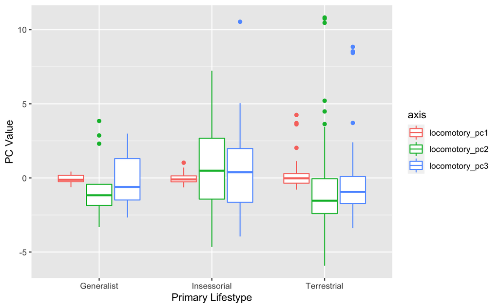

```r
avonet_jetz %>%
  pivot_longer(cols = c('locomotory_pc1', 'locomotory_pc2', 'locomotory_pc3'), names_to = 'axis') %>%
  ggplot(aes(x = primary_lifestyle, y = value, color = axis)) +
    geom_boxplot() + xlab('Primary Lifestype') + ylab('PC Value')
```

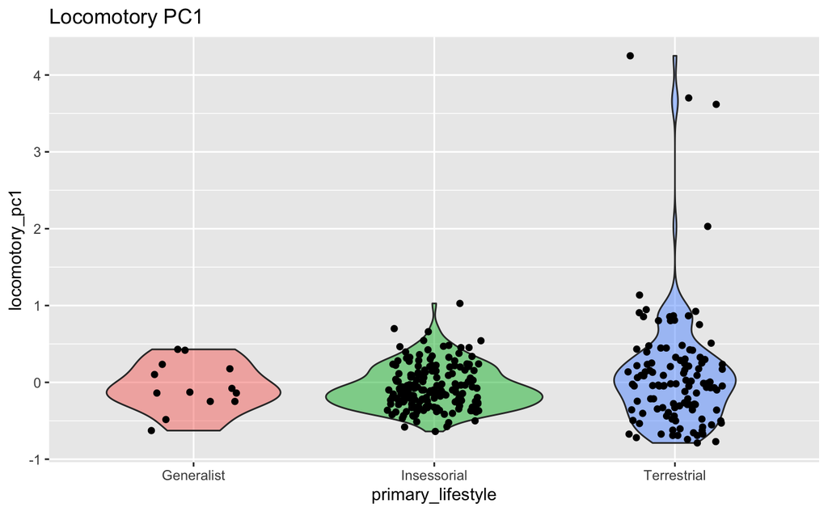

```r
avonet_jetz %>%
  ggplot(aes(x = primary_lifestyle, y = locomotory_pc1, fill = primary_lifestyle)) +
    geom_violin(alpha = 0.5) +
    geom_point(position = position_jitter(seed = 1, width = 0.2)) +
    theme(legend.position = "none") +
    labs(title = "Locomotory PC1")
```

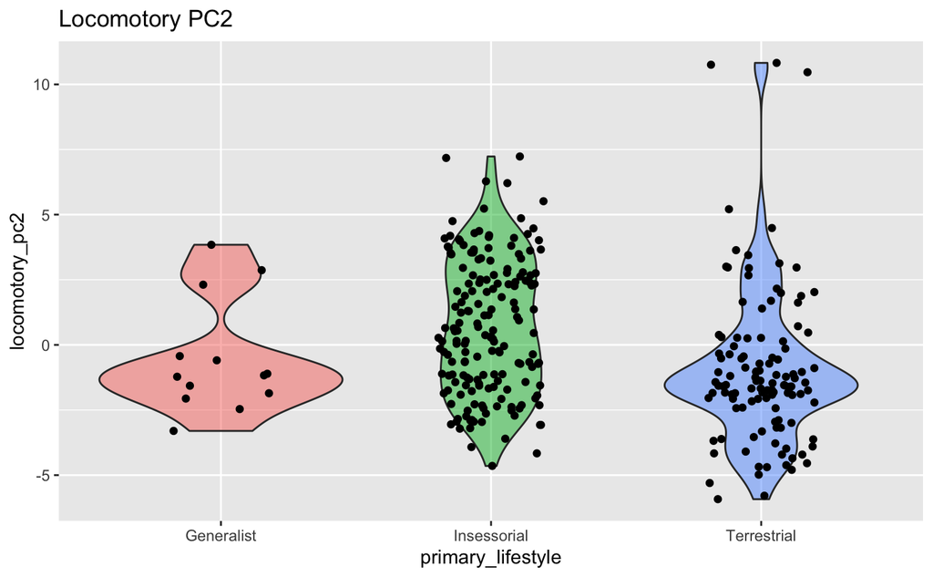

```r
avonet_jetz %>%
  ggplot(aes(x = primary_lifestyle, y = locomotory_pc2, fill = primary_lifestyle)) +
    geom_violin(alpha = 0.5) +
    geom_point(position = position_jitter(seed = 1, width = 0.2)) +
    theme(legend.position = "none") +
    labs(title = "Locomotory PC2")
```

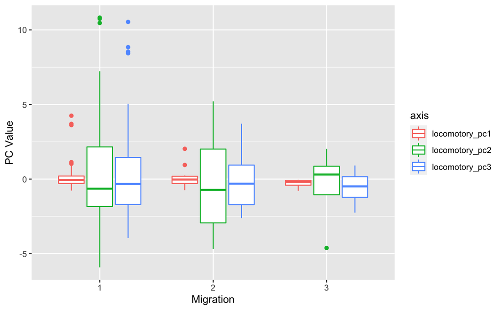

```r
avonet_jetz %>%
  pivot_longer(cols = c('locomotory_pc1', 'locomotory_pc2', 'locomotory_pc3'), names_to = 'axis') %>%
  ggplot(aes(x = migration, y = value, color = axis)) +
    geom_boxplot() + xlab('Migration') + ylab('PC Value')
```

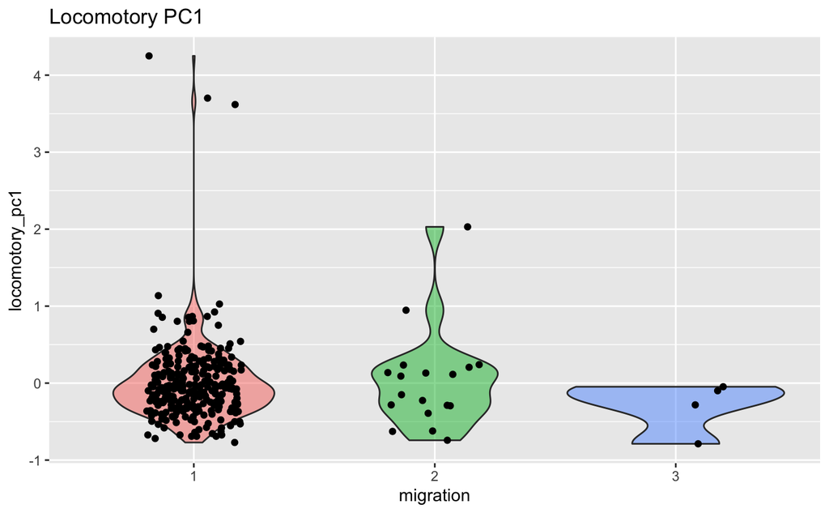

```r
avonet_jetz %>%
  ggplot(aes(x = migration, y = locomotory_pc1, fill = migration)) +
    geom_violin(alpha = 0.5) +
    geom_point(position = position_jitter(seed = 1, width = 0.2)) +
    theme(legend.position = "none") +
    labs(title = "Locomotory PC1")
```

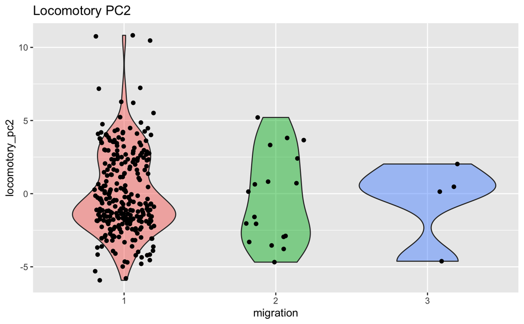

```r
avonet_jetz %>%
  ggplot(aes(x = migration, y = locomotory_pc2, fill = migration)) +
    geom_violin(alpha = 0.5) +
    geom_point(position = position_jitter(seed = 1, width = 0.2)) +
    theme(legend.position = "none") +
    labs(title = "Locomotory PC2")
```

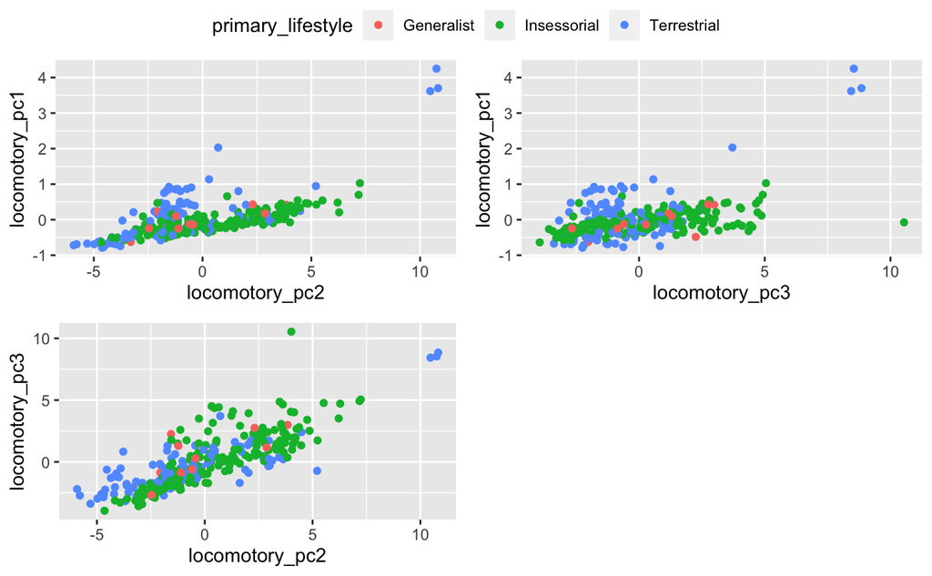

```r
ggarrange(ncol = 2, nrow = 2, common.legend = T,
          ggplot(avonet_jetz, aes(y = locomotory_pc1, x = locomotory_pc2, color = primary_lifestyle)) + geom_point(),
          ggplot(avonet_jetz, aes(y = locomotory_pc1, x = locomotory_pc3, color = primary_lifestyle)) + geom_point(),
          ggplot(avonet_jetz, aes(y = locomotory_pc3, x = locomotory_pc2, color = primary_lifestyle)) + geom_point()
)
```

Is PC1 correlated to mass?

```r
cor(avonet_jetz$locomotory_pc1, avonet_jetz$mass)
```

```
[1] 0.8332333
```

Is PC2 correlated to mass?

```r
cor(avonet_jetz$locomotory_pc2, avonet_jetz$mass)
```

```
[1] 0.7988238
```

Is PC3 correlated to mass?

```r
cor(avonet_jetz$locomotory_pc3, avonet_jetz$mass)
```

```
[1] 0.6700626
```

# Store our new trait data

```r
trait_database = avonet_jetz %>%
  dplyr::select(JetzSpeciesName, beak_width, trophic_pc2, locomotory_pc2, mass) %>%
  rename(jetz_species_name=JetzSpeciesName, gape_width=beak_width, trophic_trait=trophic_pc2, locomotory_trait=locomotory_pc2)
trait_database
```

| jetz_species_name | gape_width | trophic_trait | locomotory_trait | mass |
| --- | --- | --- | --- | --- |
| Alectroenas_madagascariensis | 4.100000 | -0.028456534 | 0.15493142 | 173.0000 |
| Alectroenas_pulcherrima | 4.500000 | -0.005477135 | -0.45402267 | 165.0000 |
| Alectroenas_sganzini | 4.400000 | -0.011221985 | -0.23571837 | 158.0000 |
| Aplopelia_larvata | 3.300000 | -0.074415334 | -1.44788170 | 155.0000 |
| Caloenas_nicobarica | 5.400000 | 0.046226514 | 5.21039933 | 537.9000 |
| Chalcophaps_indica | 2.950000 | -0.094522308 | -1.16925648 | 136.5000 |
| Chalcophaps_stephani | 2.600000 | -0.114629283 | -1.85576604 | 129.0000 |
| Claravis_godefrida | 3.400000 | -0.068670484 | -2.88983902 | 43.5000 |
| Claravis_mondetoura | 2.800000 | -0.103139583 | -2.95303237 | 89.7000 |
| Claravis_pretiosa | 3.200000 | -0.080160184 | -3.30346822 | 68.2000 |

[output cut: 294 more lines]

```r
write_csv(trait_database, filename(TAXONOMY_OUTPUT_DIR, 'traits_jetz.csv'))
```

“AVONET: Morphological, Ecological and Geographical Data for All Birds.” 2022. Ecology Letters. https://doi.org/10.1111/ele.13898.

Tom P. Bregman, Hannah E. A. MacGregor, Alexander C. Lees, and Joseph A. Tobias. 2016. “Using Avian Functional Traits to Assess the Impact of Land-Cover Change on Ecosystem Processes Linked to Resilience in Tropical Forests” 283 (1844). https://doi.org/10.1098/rspb.2016.1289.

Trisos, Petchey, C. H. 2014. “Unraveling the Interplay of Community Assembly Processes Acting on Multiple Niche Axes Across Spatial Scales” 184 (5). https://doi.org/10.1086/678233.